# What does it take to win games in the NBA?

### Identifying what stats can predict win percentage.

##### Andrew Cunniff, Tanmay Dhal

## Introduction

The NBA (National Basketball Association) is known to be the best basketball league in the world. In the current 2019-2020 season, there have been a total of 370 total games played, each team with around 25 games under their belt. Since an NBA season consists of 82 games, we are currently only 30% into the season, not including playoffs. Some foolish people think that a team’s current record is all that’s needed to predict their record at the end of the regular season, but that is never the case. There are so many different variables that play a major part in a team's win rate, so a record doesn’t mean too much when predicting the winner. Since there are so many different variables in every game, we aim to determine which variables have the strongest prediction power on predicting a team's record. Our end goal for this tutorial is to develop a multiple regression equation to accurately predict a team's winning percentage at the end of the regular season. However, there are endless applications for this tutorial. This outline can be utilized for any kind of datasets that you want to explore.

## Outline

##### 1. Getting Started

- 1.1 Required Libraries
- 1.2 Dataset Source
- 1.3 Load and View Data
- 1.4 Cleaning Data

##### 2. Explore Teams

- 2.1 Teams by position currently in the season
- 2.2 What makes the top teams good(Stats)

##### 3. Explore Variables

- 3.1 Plotting Relationships
- 3.2 Analyzing Correlations

##### 4. Reveal Key Attributes with Multiple Linear Regression

- 4.1 Null Hypothesis
- 4.2 Regression with scikit-learn
- 4.3 Regression with statsmodels

##### 5. Predict Rating From Attributes with Machine Learning

- 5.1 Predictions with Train/Test Split

##### 6. Conclusions

- 6.1 Key Attributes
- 6.2 Prediction of Overall Rating

# 1. Getting Started

## 1.1 Required Libraries

Libraries - For this project, we will be making use of a host of python libraries. They are described in order as below:

- Pandas - The python Pandas library will be used to extract data from our data sources and structure the data with the help of dataframes. Pandas makes it convenient to structure statistical data, and its dataframes allow for convenient manipulation of data.
- Numpy - This is the fundamental package for scientific computing in Python. It has powerful features like an N-dimensional array, linear algebra, Fourier transform and random numbers.
- Matplotlib - This is a python 2D plotting library and has the ability to produce interactive figures across different platforms. We will be using this library to generate scatter plots, bar graphs and histograms among other things
- Sci-kit learn - This is another python library which provides data exploratory tools for predictive data analysis.
- Seaborn - Another very helpful python library for plotting and displaying data in different formats.
- StatsModel - Useful for multiple regression

```python
import pandas as pd
import numpy as np
import matplotlib.pyplot as plt
from sklearn.model_selection import train_test_split
from sklearn.linear_model import LinearRegression
from sklearn import metrics
from sklearn.datasets import make_regression
import seaborn as sns
import statsmodels.api as sm
import statsmodels.formula.api as smf
from sklearn import datasets
from sklearn import svm
from sklearn.model_selection import cross_val_score
from sklearn import model_selection
from tqdm import tnrange, tqdm_notebook
import itertools
import time
from sklearn import linear_model
from sklearn.metrics import mean_squared_error
```

## 1.2 Dataset Source

###### All of our data comes from www.basketball-reference.com. This website has stats for everything basketball related, and provides the ability to convert any table into .csv format. Due to this feature, we did not directly scrape the data ourselves. The data that we targeted includes: team data per 100 possessions and team standings data for the 2018-2019 and 2019-2020 seasons. Since an average game consists of around 100 possessions per team, we thought using data standardized by possession rather than by game would be more useful. That team data consists of variables like points, field goal percentage, turnovers, etc. The standings data has each team's overall record, home and road record, record by month, etc.

###### Here are the links to the data for each season:

- 2018-2019: https://www.basketball-reference.com/leagues/NBA_2019.html
- 2019-2020: https://www.basketball-reference.com/leagues/NBA_2020.html

## 1.3 Load and View Data

###### Let's load the .csv files and see what they look like

```python
curr = pd.read_csv("teamper100.csv", sep=',')
currec = pd.read_csv("currec.csv", sep=',')
last = pd.read_csv("last.csv", sep=',')
lastrec = pd.read_csv("lastrec.csv", sep=',')
display(curr.head())
display(currec.head())
display(last.head())
display(lastrec.head())
```

|  | Rk | Team | G | MP | FG | FGA | FGPC | THP | THPA | THPPC | ... | FTPC | ORB | DRB | TRB | AST | STL | BLK | TOV | PF | PTS |
| --- | --- | --- | --- | --- | --- | --- | --- | --- | --- | --- | --- | --- | --- | --- | --- | --- | --- | --- | --- | --- | --- |
| 0 | 1 | Milwaukee Bucks | 27 | 6505 | 42.0 | 86.2 | 0.487 | 13.5 | 37.3 | 0.362 | ... | 0.726 | 9.4 | 39.2 | 48.6 | 24.5 | 7.4 | 5.5 | 14.1 | 19.1 | 114.8 |
| 1 | 2 | Los Angeles Clippers | 28 | 6745 | 39.7 | 87.0 | 0.457 | 11.2 | 31.4 | 0.357 | ... | 0.784 | 11.0 | 36.1 | 47.1 | 22.3 | 7.4 | 5.1 | 15.7 | 22.2 | 111.2 |
| 2 | 3 | Houston Rockets | 26 | 6290 | 39.3 | 87.2 | 0.451 | 15.3 | 43.8 | 0.348 | ... | 0.794 | 10.9 | 34.7 | 45.6 | 20.8 | 8.1 | 4.9 | 14.7 | 21.3 | 114.9 |
| 3 | 4 | Philadelphia 76ers | 27 | 6505 | 40.9 | 85.8 | 0.477 | 10.8 | 29.2 | 0.370 | ... | 0.744 | 9.5 | 36.6 | 46.1 | 26.7 | 8.6 | 5.8 | 16.1 | 22.0 | 109.8 |
| 4 | 5 | Los Angeles Lakers | 26 | 6265 | 42.6 | 87.5 | 0.487 | 11.1 | 30.0 | 0.369 | ... | 0.734 | 9.9 | 35.2 | 45.1 | 26.1 | 8.6 | 7.0 | 14.9 | 19.8 | 112.6 |

5 rows × 25 columns

|  | Rk | Team | Overall | Home | Road | E | W | A | C | SE | ... | Post | ≤3 | ≥10 | Oct | Nov | Dec | Jan | Feb | Mar | Apr |
| --- | --- | --- | --- | --- | --- | --- | --- | --- | --- | --- | --- | --- | --- | --- | --- | --- | --- | --- | --- | --- | --- |
| 0 | 1 | Milwaukee Bucks | 24-3 | 13-1 | 11-2 | 15-2 | 9-1 | 2-1 | 8-0 | 5-1 | ... | 0-0 | 1-1 | 14-1 | 2-2 | 15-1 | 7-0 | 0-0 | 0-0 | 0-0 | 0-0 |
| 1 | 2 | Los Angeles Lakers | 23-3 | 10-2 | 13-1 | 7-1 | 16-2 | 0-1 | 1-0 | 6-0 | ... | 0-0 | 4-0 | 10-2 | 3-1 | 14-1 | 6-1 | 0-0 | 0-0 | 0-0 | 0-0 |
| 2 | 3 | Los Angeles Clippers | 20-8 | 13-1 | 7-7 | 8-3 | 12-5 | 3-0 | 1-3 | 4-0 | ... | 0-0 | 4-1 | 13-3 | 4-2 | 10-4 | 6-2 | 0-0 | 0-0 | 0-0 | 0-0 |
| 3 | 4 | Philadelphia 76ers | 20-7 | 14-0 | 6-7 | 13-3 | 7-4 | 5-1 | 5-0 | 3-2 | ... | 0-0 | 4-2 | 6-1 | 4-0 | 10-6 | 6-1 | 0-0 | 0-0 | 0-0 | 0-0 |
| 4 | 5 | Miami Heat | 19-7 | 11-1 | 8-6 | 13-2 | 6-5 | 2-2 | 6-0 | 5-0 | ... | 0-0 | 1-1 | 11-4 | 4-1 | 9-4 | 6-2 | 0-0 | 0-0 | 0-0 | 0-0 |

5 rows × 24 columns

|  | Rk | Team | G | MP | FG | FGA | FGPC | THP | THPA | THPPC | ... | FTPC | ORB | DRB | TRB | AST | STL | BLK | TOV | PF | PTS |
| --- | --- | --- | --- | --- | --- | --- | --- | --- | --- | --- | --- | --- | --- | --- | --- | --- | --- | --- | --- | --- | --- |
| 0 | 1 | Milwaukee Bucks | 82 | 19780 | 41.8 | 87.8 | 0.476 | 13.0 | 36.8 | 0.353 | ... | 0.773 | 9.0 | 39.0 | 47.9 | 25.1 | 7.2 | 5.7 | 13.4 | 18.9 | 113.8 |
| 1 | 2 | Golden State Warriors | 82 | 19805 | 43.4 | 88.4 | 0.491 | 13.1 | 33.9 | 0.385 | ... | 0.801 | 9.6 | 35.9 | 45.5 | 29.0 | 7.5 | 6.3 | 14.0 | 21.1 | 115.9 |
| 2 | 3 | New Orleans Pelicans | 82 | 19755 | 42.1 | 89.0 | 0.473 | 9.9 | 28.8 | 0.344 | ... | 0.761 | 10.7 | 34.9 | 45.6 | 26.1 | 7.2 | 5.2 | 14.3 | 20.4 | 111.4 |
| 3 | 4 | Philadelphia 76ers | 82 | 19805 | 40.6 | 86.2 | 0.471 | 10.6 | 29.5 | 0.359 | ... | 0.771 | 10.6 | 36.1 | 46.7 | 26.3 | 7.2 | 5.2 | 14.6 | 20.8 | 112.6 |
| 4 | 5 | Los Angeles Clippers | 82 | 19830 | 40.3 | 85.4 | 0.471 | 9.8 | 25.2 | 0.388 | ... | 0.792 | 9.5 | 34.9 | 44.4 | 23.4 | 6.7 | 4.6 | 14.2 | 22.8 | 112.4 |

5 rows × 25 columns

|  | Rk | Team | Overall | Home | Road | E | W | A | C | SE | ... | Post | ≤3 | ≥10 | Oct | Nov | Dec | Jan | Feb | Mar | Apr |
| --- | --- | --- | --- | --- | --- | --- | --- | --- | --- | --- | --- | --- | --- | --- | --- | --- | --- | --- | --- | --- | --- |
| 0 | 1 | Milwaukee Bucks | 60-22 | 33-8 | 27-14 | 40-12 | 20-10 | 13-5 | 14-2 | 13-5 | ... | 17-8 | 5-6 | 45-5 | 7-0 | 8-6 | 10-4 | 12-3 | 10-1 | 10-6 | 3-2 |
| 1 | 2 | Toronto Raptors | 58-24 | 32-9 | 26-15 | 36-16 | 22-8 | 12-4 | 10-8 | 14-4 | ... | 15-8 | 11-7 | 33-9 | 7-1 | 12-3 | 8-7 | 10-5 | 8-1 | 9-6 | 4-1 |
| 2 | 3 | Golden State Warriors | 57-25 | 30-11 | 27-14 | 22-8 | 35-17 | 6-4 | 8-2 | 8-2 | ... | 16-9 | 7-7 | 34-10 | 8-1 | 7-7 | 10-5 | 11-2 | 7-4 | 9-5 | 5-1 |
| 3 | 4 | Denver Nuggets | 54-28 | 34-7 | 20-21 | 20-10 | 34-18 | 7-3 | 6-4 | 7-3 | ... | 15-10 | 13-3 | 23-11 | 6-1 | 9-6 | 8-4 | 12-4 | 7-4 | 9-6 | 3-3 |
| 4 | 5 | Houston Rockets | 53-29 | 31-10 | 22-19 | 21-9 | 32-20 | 8-2 | 6-4 | 7-3 | ... | 20-5 | 5-7 | 29-12 | 1-5 | 9-6 | 11-4 | 8-6 | 8-4 | 12-3 | 4-1 |

5 rows × 24 columns

##### The curr (1st dataframe displayed) contains the team stats per 100 possessions for the 2019-2020 season.The currec file(2nd) contains the 2019-2020 current standings, last (3rd) is team stats per 100 poss. for the 2018-2019 season, and lastrec (4th) is 2018-2019 regular season standings.

##### Here is a key to understand the variable names and lookup for the future sections.

```python
display(pd.read_csv("key.csv", sep=','))
```

|  | variable | meaning |
| --- | --- | --- |
| 0 | Rk | rank |
| 1 | Team | team name |
| 2 | G | games played |
| 3 | MP | minutes played |
| 4 | FG | number of field goals made |
| 5 | FGA | number of field goals attempted |
| 6 | FGPC | shooting percentage |
| 7 | THPC | number of 3-pointers made |
| 8 | THPA | number of 3-pointers attempted |
| 9 | THPPC | 3-point shooting percentage |
| 10 | TWOPC | number of 2-pointers made |
| 11 | TWOPA | number of 2-pointers attempted |
| 12 | TWOPPC | 2-pointer shooting percentage |
| 13 | FT | number of free throws made |
| 14 | FTA | number of free throws attempted |
| 15 | FTPC | free throw shooting percentage |
| 16 | ORB | offensive rebounds |
| 17 | DRB | defensive rebounds |
| 18 | TRB | total rebounds |
| 19 | AST | assists |
| 20 | STL | steals |
| 21 | BLK | blocks |
| 22 | TOV | turnovers |
| 23 | PF | personal fouls |
| 24 | PTS | points |

## 1.4 Cleaning Data

###### As you can see, the standings data is a bit in depth, so we'll just take the overall records, convert them to winning percentage, and add it as a column to the team stats dataframe. We created a simple function (winpct) to convert from "W-L" to a winning percent of type float. Another problem we have is that the order of teams is different for the various data sets. We want the order of the overall win% to be in the same order as the team stats, so we will reindex the standings data then transfer the win% data over. There is still more cleaning to be done, but we want to visualize the data before we make any changes.

```python
def winpct(rec):
    wins = float(rec[:rec.index('-')])
    tot = float(rec[rec.index('-')+1:]) + wins
    if tot != 0:
        return wins/tot
    else:
        return -1.0

temp = []
for i in currec.Overall:
    temp.append(winpct(i))
curr = curr.set_index('Team')
curr = curr.reindex(index=currec['Team'])
curr = curr.reset_index()
curr['ovr'] = temp

temp = []
for i in lastrec.Overall:
    temp.append(winpct(i))
last = last.set_index('Team')
last = last.reindex(index=lastrec['Team'])
last = last.reset_index()
last['ovr'] = temp
```

# 2. Explore the 2019-2020 season

## 2.1 Team winning percentage in 2019-2020 so far

###### In the previous section, we see that the standings dataframe contains monthly records, so let's create a graph to see the changes in cumulative winning percentage by month. The NBA season started in October and it is only December at the current point in the season, so we'll show the changes for this period. We wrote a function to convert the data from the file to plottable float types. We'll tidy the data returned by the function, and create a group plot. The x-axis is the month in number form, and the y-axis is winning percentage.

```python
def monthly_record(df):
    newoct = []
    newnov = []
    newdec = []
    for idx,row in df.iterrows():
        octrec = row['Oct']
        octw = float(octrec[:octrec.index('-')])
        octt = float(octrec[octrec.index('-')+1:]) + octw
        newoct.append(octw/octt)

        novrec = row['Nov']
        novw = float(novrec[:novrec.index('-')])
        novt = float(novrec[novrec.index('-')+1:]) + novw
        newnov.append((novw+octw)/(novt+octt))

        decrec = row['Dec']
        decw = float(decrec[:decrec.index('-')])
        dect = float(decrec[decrec.index('-')+1:]) + decw
        newdec.append((decw+novw+octw)/(dect+novt+octt))
    return pd.DataFrame({'Team':df.Team,9:[0]*30,10:newoct,11:newnov,12:newdec})
```

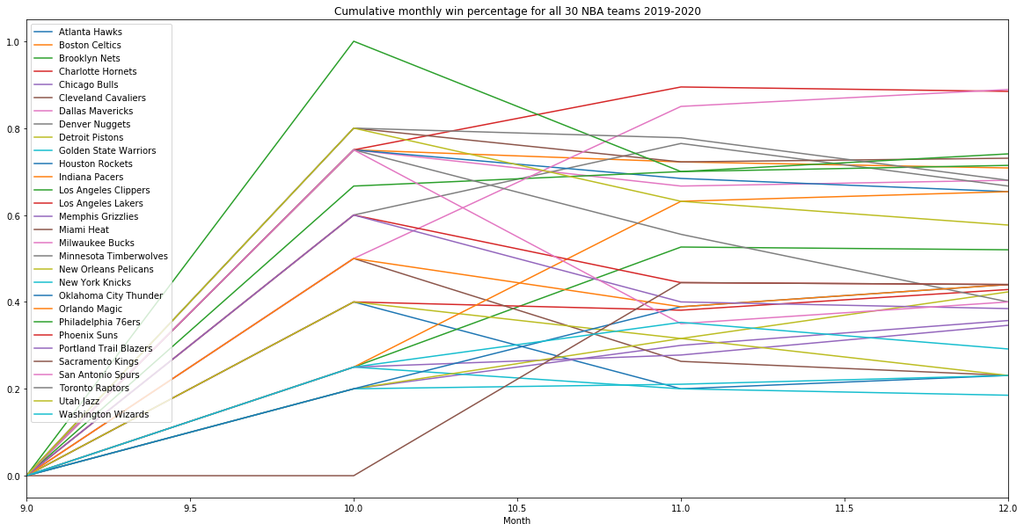

```python
monthly = monthly_record(currec)
monthly = monthly.melt(id_vars = 'Team', value_vars = [9,10,11,12], var_name = 'Month', value_name = 'winpct')

fig, ax = plt.subplots()
for label, grp in monthly.groupby('Team'):
    grp.plot(x = 'Month', y = 'winpct', ax = ax, label = label, figsize = (20,10),title="Cumulative monthly win percentage for all 30 NBA teams 2019-2020")
```

## 2.2 What stats appear to correlate with winning percentage?

Before we visualize any specific relationships with winning percentage, let's see if we can make any general observations. We'll print out the stats of the 5 best teams and the 5 worst teams at the current moment, and decide on which variables we should keep for further inspection.

```python
pd.set_option('display.max_columns', None)
print(curr.head())
print(curr.tail())
curr.drop(['Rk','G','MP'],axis=1,inplace=True)
last.drop(['Rk','G','MP'],axis=1,inplace=True)
```

```
                   Team  Rk   G    MP    FG   FGA   FGPC   THP  THPA  THPPC  \
0       Milwaukee Bucks   1  27  6505  42.0  86.2  0.487  13.5  37.3  0.362
1    Los Angeles Lakers   5  26  6265  42.6  87.5  0.487  11.1  30.0  0.369
2  Los Angeles Clippers   2  28  6745  39.7  87.0  0.457  11.2  31.4  0.357
3    Philadelphia 76ers   4  27  6505  40.9  85.8  0.477  10.8  29.2  0.370
4            Miami Heat  11  26  6365  39.1  82.9  0.472  12.5  32.8  0.379

   TWOP  TWOPA  TWOPPC    FT   FTA   FTPC   ORB   DRB   TRB   AST  STL  BLK  \
0  28.5   49.0   0.583  17.3  23.9  0.726   9.4  39.2  48.6  24.5  7.4  5.5
1  31.6   57.5   0.549  16.2  22.1  0.734   9.9  35.2  45.1  26.1  8.6  7.0
2  28.5   55.6   0.513  20.5  26.2  0.784  11.0  36.1  47.1  22.3  7.4  5.1
3  30.1   56.6   0.532  17.2  23.1  0.744   9.5  36.6  46.1  26.7  8.6  5.8
4  26.7   50.0   0.533  19.8  26.0  0.763   8.7  35.7  44.4  24.9  8.2  4.3

    TOV    PF    PTS       ovr
```

[output cut: 25 more lines]

#### Some of these variables don't make much sense/aren't what we're looking for (i.e. games played, minutes played, rank), so we dropped them from our dataframe. Now let's make a correlation matrix to see each variable's correlation with ovr.

```python
print(curr.corr()['ovr'].sort_values(ascending=False))
```

```
ovr       1.000000
DRB       0.761788
PTS       0.669997
FGPC      0.645153
TRB       0.644750
TWOPPC    0.564857
FG        0.534884
THPPC     0.497151
BLK       0.392600
AST       0.323422
THP       0.303927
FTA       0.224627
FT        0.213170
TWOP      0.154886
THPA      0.138077
STL       0.095754
FTPC     -0.020420
TOV      -0.098863
PF       -0.104866
ORB      -0.153449
FGA      -0.168539
TWOPA    -0.198351
Name: ovr, dtype: float64
```

Here, we can see that defensive rebounds, points, field goal percentage, total rebounds, and 2-pointer percentage are the top 5 correlated variables. Let's take a look at what these relationships look like in scatterplots.

# 3. Explore Variables

## 3.1 Plotting Relationships for the 2019-2020 season

We've made a function that will take a dataframe and an x and y variable name as parameters, and scatterplot the relationship (including a basic linear regression line). Let's go ahead and create a small plot for each of these variables, in order of correlation.

```python
def get_plot(df,x,y):
    plt.figure(figsize=(10,5))
    plt.plot(df[x],df[y],'ro')
    plt.xlabel(x)
    plt.ylabel(y)
    plt.title(x+' vs. '+y)
    bestfit = np.polyfit(x = df[x], y = df[y], deg = 1)
    plt.plot(df[x], df[x]*bestfit[0]+bestfit[1])
    plt.show()
    print('The linear correlation between these two variables is: '+ str(df[[x,y]].corr()[y][0]))
```

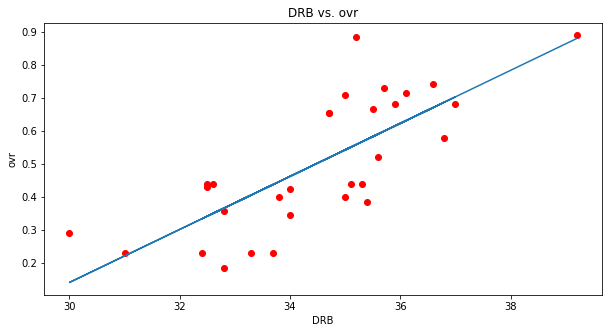

```
The linear correlation between these two variables is: 0.7617883421180136
```

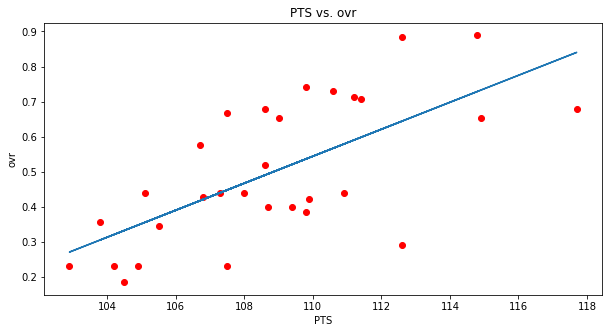

```
The linear correlation between these two variables is: 0.669996537592855
```

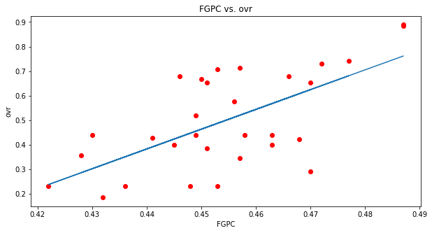

```
The linear correlation between these two variables is: 0.645152637977694
```

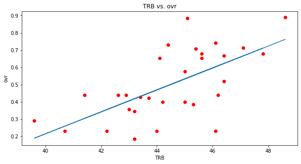

```
The linear correlation between these two variables is: 0.6447499787664964
```

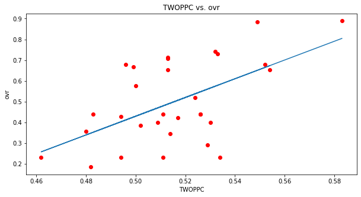

```
The linear correlation between these two variables is: 0.5648573360352646
```

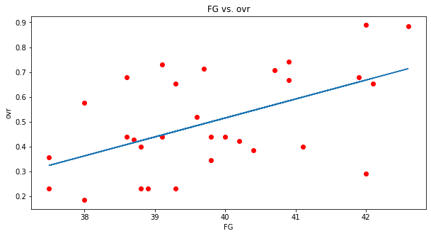

```
The linear correlation between these two variables is: 0.5348841873495328
```

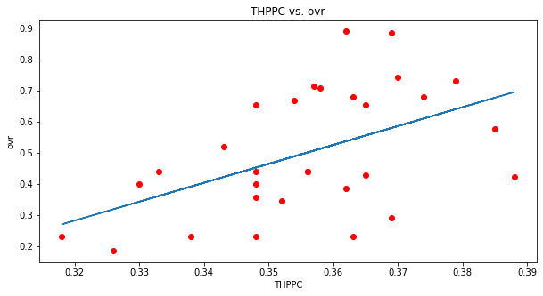

```
The linear correlation between these two variables is: 0.49715110584591543
```

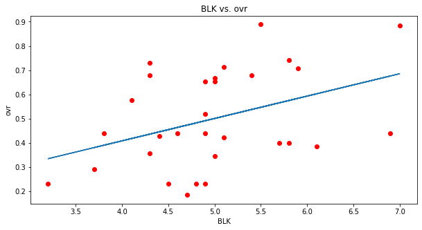

```
The linear correlation between these two variables is: 0.3926004208678108
```

```python
for x in (curr.corr()['ovr'].sort_values(ascending=False)).index[1:9]:
    get_plot(curr,x,'ovr')
```

## 3.2 Plotting Relationships for the 2018-2019 season

Since we're currently only about 30% into the 2019-2020 NBA regular season, the data set is relatively small. Let's do the same thing we did in 3.1 for the previous regular season.

```python
print(last.corr()['ovr'].sort_values(ascending=False))
```

```
ovr       1.000000
PTS       0.841132
FG        0.621811
DRB       0.616407
FGPC      0.610833
TWOPPC    0.600940
TRB       0.564500
THPPC     0.541860
AST       0.518720
THP       0.477786
BLK       0.453498
THPA      0.302795
FTPC      0.161161
FGA       0.137988
FT        0.118602
STL       0.101148
ORB       0.079407
TWOP      0.053506
FTA       0.049908
PF       -0.197731
TWOPA    -0.239296
TOV      -0.304064
Name: ovr, dtype: float64
```

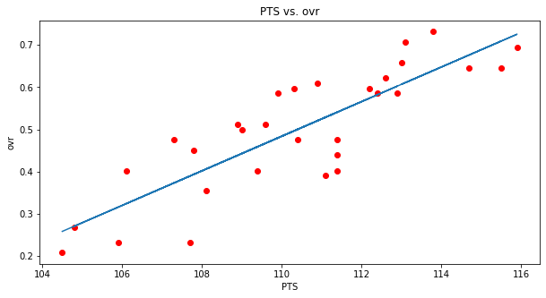

```
The linear correlation between these two variables is: 0.8411322177380848
```

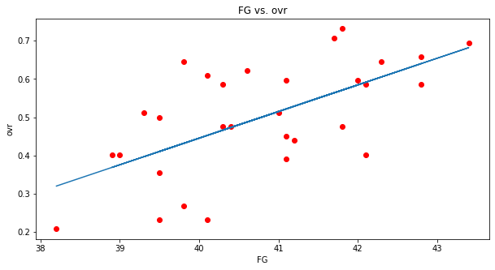

```
The linear correlation between these two variables is: 0.6218109052228273
```

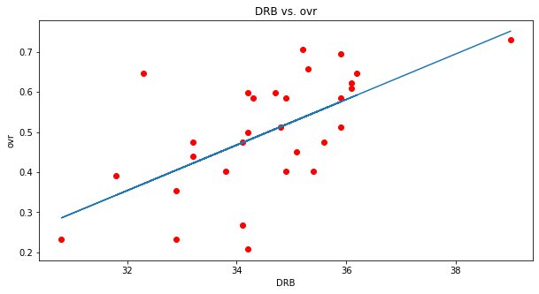

```
The linear correlation between these two variables is: 0.6164070293134132
```

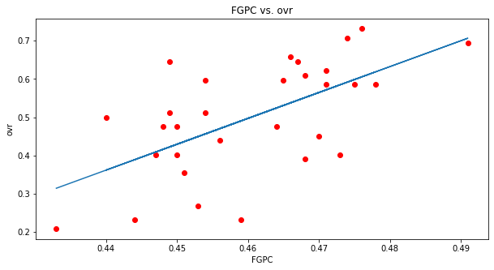

```
The linear correlation between these two variables is: 0.6108327463052614
```

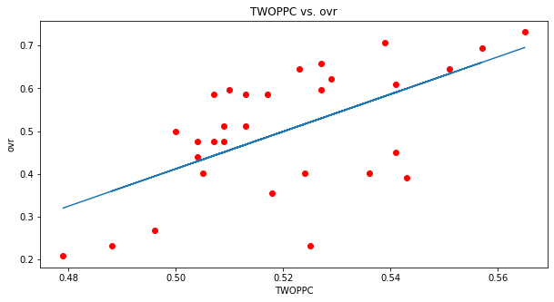

```
The linear correlation between these two variables is: 0.6009395900443963
```

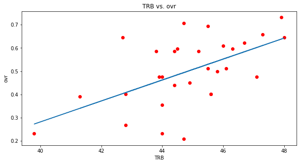

```
The linear correlation between these two variables is: 0.5644996658396283
```

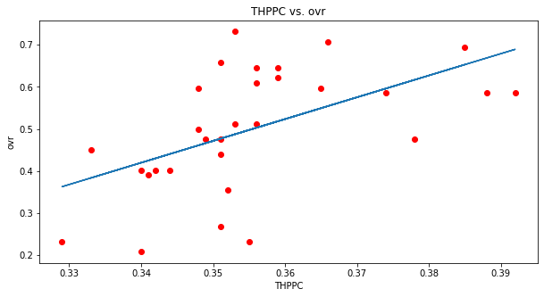

```
The linear correlation between these two variables is: 0.5418598753532115
```

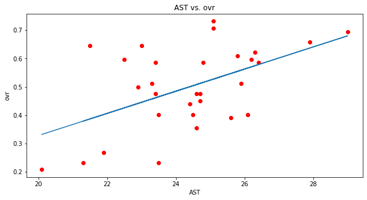

```
The linear correlation between these two variables is: 0.5187202428498239
```

```python
for x in (last.corr()['ovr'].sort_values(ascending=False)).index[1:9]:
    get_plot(last,x,'ovr')
```

These plots in order display the following:

1. Total Points acquired versus the Overall Win Percentage
2. Field Goals scored versus the Overall Win Percentage
3. Defensive Rebounds versus the Overall Win Percentage
4. Field Goal Percentage versus the Overall Win Percentage
5. Two Points Per Game Percentage scored versus the Overall Win Percentage
6. Total Rebounds Percentage versus the Overall Win Percentage
7. Three Points Per Game scored Percentage versus the Overall Win Percentage
8. Assists Per Game versus the Overall Win Percentage

# 4. Reveal key stats with Multiple Linear Regression

## 4.1 Null Hypothesis

##### Null Hypothesis: None of the variables have a significant impact on winning percentage.

We will test this null hypothesis with joint hypothesis testing using the F-statistic.

## 4.2 Regression

- If you would like to learn more about the thoery behind subset selection, check out chapter 6 in this statistical learning textbook: http://faculty.marshall.usc.edu/gareth-james/ISL/ISLR%20Seventh%20Printing.pdf.
- If you would like to learn more about the coding behind Python Regression analysis, check out the series of articles on https://medium.com/@dhwajraj.
- If you need help with coding subset selection algorithms, this notebook helps: http://www.science.smith.edu/~jcrouser/SDS293/labs/lab8-py.html.

```python
def fit_linear_reg(X,Y):
    #Fit linear regression model and return RSS and R squared values
    model_k = linear_model.LinearRegression(fit_intercept = True)
    model_k.fit(X,Y)
    RSS = mean_squared_error(Y,model_k.predict(X)) * len(Y)
    R_squared = model_k.score(X,Y)
    return RSS, R_squared

def subset_selection(df,y):
    Y = df[y]
    X = df.drop(y, axis = 1)
    k = len(df.columns)-1
    RSS_list, R_squared_list, vars_list, num_vars = [],[],[],[]

    #Looping over k = 1 to k = 11 features in X
    for k in tnrange(1,len(X.columns) + 1, desc = 'Loop...'):

        #Looping over all possible combinations
        for combo in itertools.combinations(X.columns,k):
            temp = fit_linear_reg(X[list(combo)],Y)   #Store temp result
            RSS_list.append(temp[0])                  #Append lists
            R_squared_list.append(temp[1])
            vars_list.append(combo)
            num_vars.append(len(combo))

    #Store in DataFrame
    rdf = pd.DataFrame({'num_vars': num_vars,'RSS': RSS_list, 'R_squared':R_squared_list,'vars':vars_list})
    df_max = rdf[rdf.groupby('num_vars')['R_squared'].transform(max) == rdf['R_squared']]
    display(df_max.head(k))
    return df_max
```

In the next two code snippets, we are creating the optimal regression formula with 6 variables for both the current season and last season (eqc/eql).

```python
keepc = (curr.corr()['ovr'].sort_values(ascending=False)).index[:13]
eqc = (subset_selection(curr[keepc],'ovr')).reset_index().iloc[5,4]
eqc = 'ovr ~ ' + '+'.join(eqc)
print('Multiple Regression formula for current season: '+eqc)
```

|  | num_vars | RSS | R_squared | vars |
| --- | --- | --- | --- | --- |
| 0 | 1 | 0.495720 | 0.580321 | (DRB,) |
| 33 | 2 | 0.301672 | 0.744603 | (FGPC, TRB) |
| 84 | 3 | 0.259083 | 0.780660 | (DRB, PTS, AST) |
| 333 | 4 | 0.247376 | 0.790570 | (DRB, PTS, BLK, AST) |
| 891 | 5 | 0.226215 | 0.808486 | (DRB, PTS, FG, THP, FT) |
| 1768 | 6 | 0.196666 | 0.833501 | (DRB, PTS, FG, THPPC, THP, FT) |
| 3025 | 7 | 0.186708 | 0.841932 | (PTS, FGPC, TRB, FG, THP, FTA, FT) |
| 3650 | 8 | 0.176417 | 0.850644 | (PTS, FGPC, TRB, TWOPPC, FG, THP, FTA, FT) |
| 3974 | 9 | 0.173886 | 0.852787 | (PTS, FGPC, TRB, TWOPPC, FG, BLK, THP, FTA, FT) |
| 4076 | 10 | 0.171456 | 0.854844 | (PTS, FGPC, TRB, TWOPPC, FG, BLK, AST, THP, FT... |
| 4087 | 11 | 0.171045 | 0.855192 | (DRB, PTS, FGPC, TRB, TWOPPC, FG, BLK, AST, TH... |
| 4094 | 12 | 0.170867 | 0.855343 | (DRB, PTS, FGPC, TRB, TWOPPC, FG, THPPC, BLK, ... |

```
Multiple Regression formula for current season: ovr ~ DRB+PTS+FG+THPPC+THP+FT
```

Above is the table containing the information when we factor in variables starting with 1 variable and slowly adding another variable in each iteration. (This is for the Current Season)

```python
keepl = (last.corr()['ovr'].sort_values(ascending=False)).index[:13]
eql = (subset_selection(last[keepl],'ovr')).reset_index().iloc[5,4]
eql = 'ovr ~ ' + '+'.join(eql)
print('Multiple Regression formula for last season: '+eql)
```

|  | num_vars | RSS | R_squared | vars |
| --- | --- | --- | --- | --- |
| 0 | 1 | 0.182528 | 0.707503 | (PTS,) |
| 13 | 2 | 0.118556 | 0.810017 | (PTS, DRB) |
| 96 | 3 | 0.102921 | 0.835071 | (PTS, DRB, FTPC) |
| 377 | 4 | 0.094126 | 0.849166 | (PTS, DRB, BLK, FTPC) |
| 985 | 5 | 0.085140 | 0.863565 | (PTS, DRB, THPPC, BLK, FTPC) |
| 1920 | 6 | 0.081124 | 0.870001 | (PTS, DRB, THP, BLK, THPA, FTPC) |
| 2793 | 7 | 0.080211 | 0.871464 | (PTS, DRB, FGPC, TWOPPC, THP, BLK, FTPC) |
| 3530 | 8 | 0.078131 | 0.874796 | (PTS, DRB, FGPC, TWOPPC, TRB, BLK, THPA, FTPC) |
| 3923 | 9 | 0.077638 | 0.875586 | (PTS, DRB, FGPC, TWOPPC, TRB, THPPC, THP, BLK,... |
| 4023 | 10 | 0.077080 | 0.876482 | (PTS, FG, DRB, FGPC, TWOPPC, TRB, THPPC, THP, ... |
| 4083 | 11 | 0.076964 | 0.876666 | (PTS, FG, DRB, FGPC, TWOPPC, TRB, THPPC, AST, ... |
| 4094 | 12 | 0.076939 | 0.876708 | (PTS, FG, DRB, FGPC, TWOPPC, TRB, THPPC, AST, ... |

```
Multiple Regression formula for last season: ovr ~ PTS+DRB+THP+BLK+THPA+FTPC
```

Above is the table containing the information when we factor in variables starting with 1 variable and slowly adding another variable in each iteration. (This is for the Last Season)

Next we are going to use Machine Learning to determine the coefficients for each variable in our regression formula. First, we will train the regression with 70% of the data from the current season, then predict overall win percentages with the testing set (30% of the data). We'll then show a scatterplot of the predicted values vs. actual values, with an identity line of the actual values.

# 5. Predict Rating From Attributes with Machine Learning

## 5.1 Predictions with Train/Test Split

### Train test split on current and last season's data

```python
xc = curr[keepc].drop('ovr', axis=1)
yc = curr['ovr']
xl = last[keepl].drop('ovr', axis=1)
yl = last['ovr']
```

```python
Xc_train, Xc_test, yc_train, yc_test = model_selection.train_test_split(xc, yc, test_size=.3)
Xc_train['ovr'] = yc_train

Xl_train, Xl_test, yl_train, yl_test = model_selection.train_test_split(xl, yl, test_size=.3)
Xl_train['ovr'] = yl_train
```

### Training and predicting the optimal variables for the current season's data.

```
                            OLS Regression Results
==============================================================================
Dep. Variable:                    ovr   R-squared:                       0.878
Model:                            OLS   Adj. R-squared:                  0.826
Method:                 Least Squares   F-statistic:                     16.85
Date:                Mon, 16 Dec 2019   Prob (F-statistic):           1.13e-05
Time:                        15:55:07   Log-Likelihood:                 25.860
No. Observations:                  21   AIC:                            -37.72
Df Residuals:                      14   BIC:                            -30.41
Df Model:                           6
Covariance Type:            nonrobust
==============================================================================
                 coef    std err          t      P>|t|      [0.025      0.975]
------------------------------------------------------------------------------
Intercept     -5.3954      0.811     -6.651      0.000      -7.135      -3.656
DRB            0.0599      0.016      3.645      0.003       0.025       0.095
PTS            0.7504      0.248      3.026      0.009       0.219       1.282
FG            -1.4384      0.496     -2.898      0.012      -2.503      -0.374
THPPC          1.6472      1.381      1.192      0.253      -1.316       4.610
THP           -0.7106      0.244     -2.917      0.011      -1.233      -0.188
FT            -0.7346      0.252     -2.920      0.011      -1.274      -0.195
==============================================================================
Omnibus:                        2.016   Durbin-Watson:                   2.253
Prob(Omnibus):                  0.365   Jarque-Bera (JB):                1.192
Skew:                          -0.259   Prob(JB):                        0.551
Kurtosis:                       1.954   Cond. No.                     9.26e+03
==============================================================================

Warnings:
[1] Standard Errors assume that the covariance matrix of the errors is correctly specified.
[2] The condition number is large, 9.26e+03. This might indicate that there are
strong multicollinearity or other numerical problems.
```

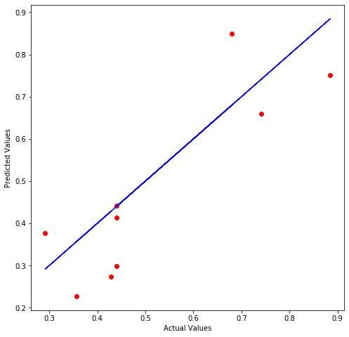

```
Residual Sum of Squares: 0.1218750477270842
```

```python
# Fit the Linear Regression on Train split
curr_lr = smf.ols(formula=eqc,data=Xc_train).fit()
print(curr_lr.summary())
Xc_test['ovr'] = yc_test
# Predict using Test split
curr_pred = curr_lr.predict(Xc_test)
plt.figure(figsize=(8,8))
plt.plot(yc_test,curr_pred,'ro')
plt.plot(yc_test,yc_test,color='Blue')
plt.xlabel("Actual Values")
plt.ylabel("Predicted Values")
plt.show()
comp = pd.DataFrame({'pred':curr_pred,'acc':Xc_test['ovr']})
comp['res'] = (comp['acc'] - comp['pred'])**2
print("Residual Sum of Squares: "+ str(comp['res'].sum()))
```

After doing the train split test, we get the above results. Above, we can see that the R-Squared value and the F-Statistic is quite high. With a significance level of .1, we only need an F-Statistic of at least 3.95 to reject the null hypothesis. However, let's try the same process with last season's data.

### Training and predicting the optimal variables for last season's data.

```
                            OLS Regression Results
==============================================================================
Dep. Variable:                    ovr   R-squared:                       0.881
Model:                            OLS   Adj. R-squared:                  0.831
Method:                 Least Squares   F-statistic:                     17.34
Date:                Mon, 16 Dec 2019   Prob (F-statistic):           9.53e-06
Time:                        15:55:07   Log-Likelihood:                 32.775
No. Observations:                  21   AIC:                            -51.55
Df Residuals:                      14   BIC:                            -44.24
Df Model:                           6
Covariance Type:            nonrobust
==============================================================================
                 coef    std err          t      P>|t|      [0.025      0.975]
------------------------------------------------------------------------------
Intercept     -3.6467      0.653     -5.582      0.000      -5.048      -2.246
PTS            0.0319      0.007      4.857      0.000       0.018       0.046
DRB            0.0241      0.012      1.959      0.070      -0.002       0.050
THP            0.0868      0.048      1.796      0.094      -0.017       0.190
BLK            0.0347      0.024      1.421      0.177      -0.018       0.087
THPA          -0.0236      0.015     -1.552      0.143      -0.056       0.009
FTPC          -0.7868      0.497     -1.585      0.135      -1.852       0.278
==============================================================================
Omnibus:                        0.267   Durbin-Watson:                   2.156
Prob(Omnibus):                  0.875   Jarque-Bera (JB):                0.449
Skew:                           0.106   Prob(JB):                        0.799
Kurtosis:                       2.316   Cond. No.                     6.11e+03
==============================================================================

Warnings:
[1] Standard Errors assume that the covariance matrix of the errors is correctly specified.
[2] The condition number is large, 6.11e+03. This might indicate that there are
strong multicollinearity or other numerical problems.
```

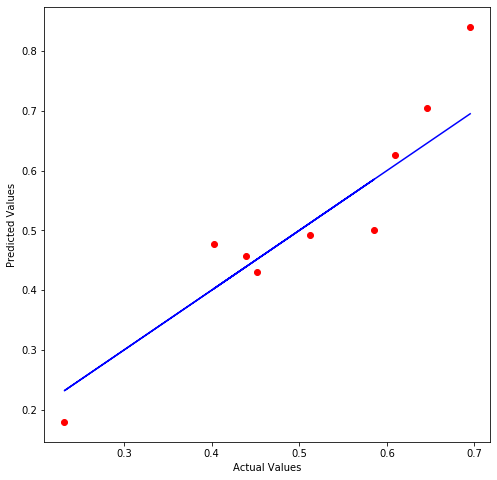

```
Residual Sum of Squares: 0.0417806847895173
```

```python
# Fit the Linear Regression on Train split
last_lr = smf.ols(formula=eql, data=Xl_train).fit()
print(last_lr.summary())
Xl_test['ovr'] = yl_test
# Predict using Test split
last_pred = last_lr.predict(Xl_test)
plt.figure(figsize=(8,8))
plt.plot(yl_test,last_pred,'ro')
plt.plot(yl_test,yl_test,color='Blue')
plt.xlabel("Actual Values")
plt.ylabel("Predicted Values")
plt.show()
comp = pd.DataFrame({'pred':last_pred,'acc':Xl_test['ovr']})
comp['res'] = (comp['acc'] - comp['pred'])**2
print("Residual Sum of Squares: "+ str(comp['res'].sum()))
```

```
                            OLS Regression Results
==============================================================================
Dep. Variable:                    ovr   R-squared:                       0.766
Model:                            OLS   Adj. R-squared:                  0.705
Method:                 Least Squares   F-statistic:                     12.55
Date:                Mon, 16 Dec 2019   Prob (F-statistic):           2.89e-06
Time:                        15:55:07   Log-Likelihood:                 27.743
No. Observations:                  30   AIC:                            -41.49
Df Residuals:                      23   BIC:                            -31.68
Df Model:                           6
Covariance Type:            nonrobust
==============================================================================
                 coef    std err          t      P>|t|      [0.025      0.975]
------------------------------------------------------------------------------
Intercept     -3.5784      0.824     -4.345      0.000      -5.282      -1.875
PTS            0.0229      0.009      2.676      0.013       0.005       0.041
DRB            0.0490      0.014      3.619      0.001       0.021       0.077
THP            0.0660      0.044      1.510      0.145      -0.024       0.156
BLK            0.0360      0.028      1.269      0.217      -0.023       0.095
THPA          -0.0250      0.015     -1.645      0.114      -0.056       0.006
FTPC          -0.2978      0.688     -0.433      0.669      -1.721       1.125
==============================================================================
Omnibus:                        1.723   Durbin-Watson:                   1.252
Prob(Omnibus):                  0.423   Jarque-Bera (JB):                1.537
Skew:                          -0.439   Prob(JB):                        0.464
Kurtosis:                       2.322   Cond. No.                     5.49e+03
==============================================================================

Warnings:
[1] Standard Errors assume that the covariance matrix of the errors is correctly specified.
[2] The condition number is large, 5.49e+03. This might indicate that there are
strong multicollinearity or other numerical problems.
```

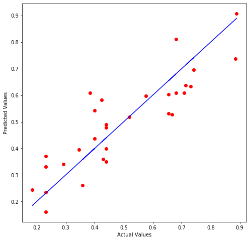

```
Residual Sum of Squares: 0.276309876921249
```

```python
# Fit the Linear Regression on Train split
_lr = smf.ols(formula=eql,data=curr).fit()
print(_lr.summary())
# Predict using Test split
curr_pred_from_last = _lr.predict(curr)
plt.figure(figsize=(8,8))
plt.plot(curr['ovr'],curr_pred_from_last,'ro')
plt.plot(curr['ovr'],curr['ovr'],color='Blue')
plt.xlabel("Actual Values")
plt.ylabel("Predicted Values")
plt.show()
comp = pd.DataFrame({'pred':curr_pred_from_last,'acc':curr['ovr']})
comp['res'] = (comp['acc'] - comp['pred'])**2
print("Residual Sum of Squares: "+ str(comp['res'].sum()))
```

We see that these regression results are not as strong as the last two, yet it still has a high R-Squared and an F-Statistic greater than the null rejection threshold.

### We reject the null hypothesis with 90% confidence as our F-Statistic is higher than the threshold of 3.95.

# 6. Conclusions

## 6.2 Takeaways

#### Our model needs more data to be tested in order to pull it closer to the realistic ranking but this model is a good starting point for anyone looking to get into multiple regression analysis. However, there are plenty of large datasets that are perfect targets for this kind of analysis since it is so versatile.